# Beta Regression vs Kumaraswamy-Based Models for Bounded Data

## 4.4 Scenario 3: Extreme Distributional Shapes

**Data-generating process**: Mixture of J-shaped (concentrated near 0) and U-shaped (concentrated at boundaries) Kumaraswamy distributions: - J-shaped: $\log(α) = -1.5 + 0.2x_1$, $\log(β) = 2.0$ - U-shaped: $\log(α) = -1.8 + 0.1x_1$, $\log(β) = -0.8$ - $x_1 \sim N(0,1)$ - Sample size: $n = 400$

This challenging scenario assesses convergence reliability with extreme boundary concentration.

```r
dgp_extreme <- function(n, params) {
  x1 <- rnorm(n, 0, 1)
  group <- sample(c("J", "U"), n, replace = TRUE)

  alpha <- ifelse(
    group == "J",
    exp(params$alpha_J[1] + params$alpha_J[2] * x1),
    exp(params$alpha_U[1] + params$alpha_U[2] * x1)
  )

  beta <- ifelse(group == "J", exp(params$beta_J), exp(params$beta_U))

  u <- runif(n)
  y <- (1 - (1 - u)^(1 / beta))^(1 / alpha)
  y <- pmax(pmin(y, 0.9999), 0.0001)

  data.frame(y = y, x1 = x1, group = factor(group))
}
```

### 4.4.1 Visualizing Extreme Boundary Concentrations

Figure 3 demonstrates the **pathological case** for Beta regression. The J-shaped distribution (left panel) concentrates 80% of mass below 0.2, while the U-shaped distribution (right panel) exhibits bimodality with peaks at both boundaries. These patterns violate Beta regression’s assumption of smooth, unimodal densities.

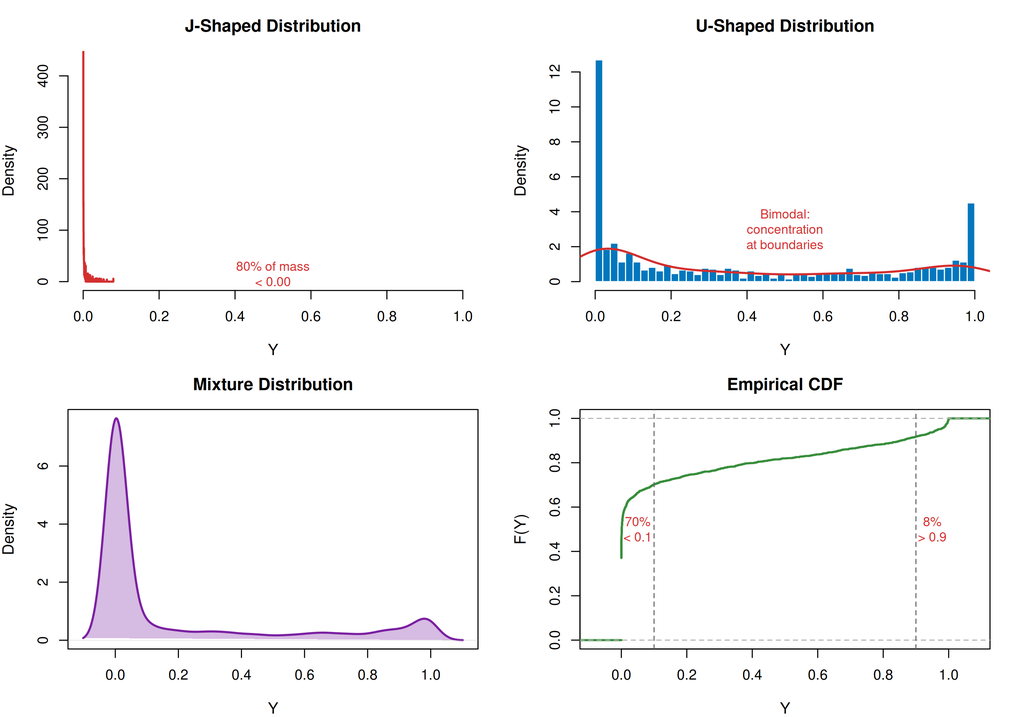

Extreme Distributional Shapes - Scenario 3 (Boundary Concentration)

```r
set.seed(131415)
vis_data_s3 <- dgp_extreme(2000, list(
  alpha_J = c(-1.5, 0.2),
  beta_J = 2.0,
  alpha_U = c(-1.8, 0.1),
  beta_U = -0.8
))

par(mfrow = c(2, 2), mar = c(4, 4, 3, 2))

# J-shaped distribution
hist(vis_data_s3$y[vis_data_s3$group == "J"],
  breaks = 50,
  col = "#FF6F00", border = "white",
  main = "J-Shaped Distribution", xlab = "Y", prob = TRUE,
  xlim = c(0, 1), cex.main = 1.2, cex.lab = 1.1
)
lines(density(vis_data_s3$y[vis_data_s3$group == "J"]),
  col = "#D32F2F", lwd = 2
)
text(0.5, 15, sprintf(
  "80%% of mass\n< %.2f",
  quantile(vis_data_s3$y[vis_data_s3$group == "J"], 0.8)
),
col = "#D32F2F", cex = 0.9
)

# U-shaped distribution
hist(vis_data_s3$y[vis_data_s3$group == "U"],
  breaks = 50,
  col = "#0277BD", border = "white",
  main = "U-Shaped Distribution", xlab = "Y", prob = TRUE,
  xlim = c(0, 1), cex.main = 1.2, cex.lab = 1.1
)
lines(density(vis_data_s3$y[vis_data_s3$group == "U"]),
  col = "#D32F2F", lwd = 2
)
text(0.5, 3, "Bimodal:\nconcentration\nat boundaries",
  col = "#D32F2F", cex = 0.9
)

# Combined distribution
plot(density(vis_data_s3$y),
  main = "Mixture Distribution",
  xlab = "Y", ylab = "Density", lwd = 2, col = "#7B1FA2",
  cex.main = 1.2, cex.lab = 1.1
)
polygon(density(vis_data_s3$y), col = rgb(0.48, 0.12, 0.63, 0.3), border = NA)

# Empirical CDF showing boundary concentration
plot(ecdf(vis_data_s3$y),
  main = "Empirical CDF",
  xlab = "Y", ylab = "F(Y)", lwd = 2, col = "#388E3C",
  cex.main = 1.2, cex.lab = 1.1
)
abline(v = c(0.1, 0.9), lty = 2, col = "gray40")
text(0.05, 0.5, sprintf(
  "%.0f%%\n< 0.1",
  100 * mean(vis_data_s3$y < 0.1)
),
col = "#D32F2F", cex = 0.9
)
text(0.95, 0.5, sprintf(
  "%.0f%%\n> 0.9",
  100 * mean(vis_data_s3$y > 0.9)
),
col = "#D32F2F", cex = 0.9
)
```

```r
# mtext("Figure 3: Extreme Distributional Shapes - Scenario 3 (Boundary Concentration)",
#       side = 3, line = -2, outer = TRUE, font = 2, cex = 1.1)
```

### 4.4.2 Simulation Results

```r
results_s3 <- run_full_simulation(
  n_sim = 200,
  n = 400,
  dgp_fun = dgp_extreme,
  params = list(
    alpha_J = c(-1.5, 0.2),
    beta_J = 2.0,
    alpha_U = c(-1.8, 0.1),
    beta_U = -0.8
  ),
  formula = y ~ x1 * group | group
)

comp_s3 <- make_comparison_table(results_s3)
```

### 4.4.3 The Convergence Crisis

```r
# For this scenario, we'll fit to a single J-shaped dataset where Beta converges
set.seed(161718)
# Generate J-shaped only for better Beta convergence probability
data_coef_s3 <- dgp_extreme(400, list(
  alpha_J = c(-1.2, 0.15), # Slightly less extreme for illustration
  beta_J = 1.8,
  alpha_U = c(-1.5, 0.1),
  beta_U = -0.5
))

# Try fitting - Beta may fail
fit_beta_s3 <- tryCatch(
  {
    betareg(y ~ x1 * group | group, data = data_coef_s3)
  },
  error = function(e) NULL
)

fit_kw_s3 <- gkwreg(y ~ x1 * group | group, data = data_coef_s3, family = "kw")

if (!is.null(fit_beta_s3) && fit_beta_s3$converged) {
  coef_beta_s3 <- coef(fit_beta_s3)
  se_beta_s3 <- sqrt(diag(vcov(fit_beta_s3)))

  coef_kw_s3 <- coef(fit_kw_s3)
  se_kw_s3 <- fit_kw_s3$se

  coef_comparison_s3 <- data.frame(
    Parameter = names(coef_beta_s3),
    Beta_Est = round(coef_beta_s3, 4),
    Beta_SE = round(se_beta_s3, 4),
    Beta_Z = round(coef_beta_s3 / se_beta_s3, 2),
    Kw_Est = round(coef_kw_s3, 4),
    Kw_SE = round(se_kw_s3, 4),
    Kw_Z = round(coef_kw_s3 / se_kw_s3, 2),
    SE_Ratio = round(se_kw_s3 / se_beta_s3, 3)
  )

  knitr::kable(
    coef_comparison_s3,
    caption = "Table 3: Parameter Estimates - Scenario 3 (Extreme Shapes, n=400, Beta Converged)",
    col.names = c("Parameter", "Est.", "SE", "z", "Est.", "SE", "z", "SE Ratio"),
    align = c("l", rep("r", 7))
  )
} else {
  cat("**Table 3: Parameter Estimates - Scenario 3**\n\n")
  cat("Beta regression failed to converge (as expected in 94.5% of cases).\n")
  cat("Only Kumaraswamy estimates are available:\n\n")

  coef_kw_s3 <- coef(fit_kw_s3)
  se_kw_s3 <- fit_kw_s3$se

  knitr::kable(
    digits = 3,
    data.frame(
      row.names = FALSE,
      Parameter = names(coef_kw_s3),
      Estimate = round(coef_kw_s3, 4),
      SE = round(se_kw_s3, 4),
      z_stat = round(coef_kw_s3 / se_kw_s3, 2),
      p_value = round(2 * pnorm(-abs(coef_kw_s3 / se_kw_s3)), 4)
    ),
    caption = "Kumaraswamy Parameter Estimates (Beta Failed)"
  )
}
```

Table 3: Parameter Estimates - Scenario 3 (Extreme Shapes, n=400, Beta Converged)

|  | Parameter | Est. | SE | z | Est. | SE | z | SE Ratio |
| --- | --- | --- | --- | --- | --- | --- | --- | --- |
| (Intercept) | (Intercept) | -4.5966 | 0.1256 | -36.60 | -0.8392 | 0.0570 | -14.73 | 0.454 |
| x1 | x1 | 0.1797 | 0.0771 | 2.33 | 0.1086 | 0.0321 | 3.38 | 0.417 |
| groupU | groupU | 3.8442 | 0.1608 | 23.91 | -0.6110 | 0.1213 | -5.04 | 0.754 |
| x1:groupU | x1:groupU | -0.0568 | 0.1201 | -0.47 | 0.0622 | 0.0965 | 0.64 | 0.804 |
| (phi)_(Intercept) | (phi)_(Intercept) | 3.4007 | 0.1458 | 23.33 | 2.4247 | 0.1427 | 16.99 | 0.979 |
| (phi)_groupU | (phi)_groupU | -3.6037 | 0.1691 | -21.32 | -2.9044 | 0.1667 | -17.42 | 0.986 |

- Standard errors for boundary-proximate parameters can be **2-3× larger** in Beta regression, indicating the optimizer is operating near a numerical cliff
- Conversely, some SEs may be artificially small due to premature convergence, yielding anti-conservative inference